# Simulations Report

About the transition probabilities

Author

Luis Alejandro Chavez

Published

January 13, 2026

# Assumptions

- **Data Source and Timeframe:**
  - Transition probabilities will be calculated using data from 2022 and 2023, taking into account changes in disease severity during this period and their association with age and modulator use.
  - Comorbidities and exacerbations will be calculated using data from 2023.
- **Definition of Disease Severity:**
  - Disease severity will be classified as mild, moderate, severe, post-transplant, lost-to-follow-up, or deceased, based on FEV1% predicted. Any individual who has undergone a lung transplant will be considered post-transplant regardless of their FEV1% predicted value.
  - An individual will be considered lost-to-follow-up if there is no FEV1% measurement in a given year and no subsequent measurements in later years.
  - The disease severity status for the year in which an individual dies will be recorded as deceased.
  - When an individual changes severity multiple times within a year, the severity for that year will be determined by the first lung function test recorded in that year.
  - The difference in FEV1% predicted will be calculated as the measurement in 2023 minus the measurement in 2022.
- **Handling Missing Data:**
  - If disease severity status is missing, individuals younger than six years with no FEV1% measurement will be classified as mild.
  - For other cases, missing disease severity will be imputed backward using the next available measured status, if there aren’t any, then the disease severity will be considered as lost-to-follow-up.
  - FEV1% predicted values themselves will not be imputed.
- **Modulator Assumptions:**
  - Only the last modulator taken by an individual will be considered.
  - All modulator effects will be computed only with individuals taking Trikafta, as it is the most widely used modulator during the study period. We will exclude individuals taking any other modulator (Orkambi, Kalydeco, Symdeko,…) to not obscure the effect of Trikafta.
  - An individual will be considered to be taking modulators only if they used modulators in both 2022 and 2023. Conversely, an individual will be considered not taking modulators if they did not use any modulators in either year.
  - Individuals who used modulators in only one of the two years will be excluded to avoid confounding transition probabilities with the timing of modulator initiation.
  - The number of years on modulators will be defined as the number of years the individual has been taking their last modulator.
  - Individuals who used modulators before 2022 but were not taking them in 2022 or 2023 will be excluded from transition probability calculations.
  - The minimum age of individuals in the CCFR taking Trikafta in 2022 is 3 years. This aligns with the approved indication in Canada, as modulators have not been tested in children younger than 2 years. Therefore, we will assume that modulators can be initiated from age 2 onwards, and individuals younger than 2 years will be excluded from further analysis.
- **Final transition and comorbidities data sets:**
  - Exclude individuals considered as lost-to-follow-up in 2023 because we do not know their disease severity status.
  - Exclude individuals less than 2 years old in 2022 and less than 3 years old in 2023 because they were not eligible for Trikafta during the period of interest.
  - Exclude individuals who were taking modulators only in 2022 or only in 2023 to better understand the effect of Trikafta.
  - Exclude individuals who were not taking modulators in 2022 nor in 2023 but had taken modulators before to better understand the effect of not taking modulators ever.
  - Exclude individuals taking modulators other than Trikafta in 2022 and in 2023 (such as Kalydeco, Symdeko, Orkambi).
  - Exclude individuals considered as lost-to-follow-up in 2023

# Descriptive statistics

| Modulator status | n | p | Years on modulator | n | p |
| --- | --- | --- | --- | --- | --- |
| Trikafta | 2289 | 0.62 | 1 to 2 years | 1332 | 0.582 |
|  |  |  | 3 years or more | 957 | 0.418 |
| None | 1401 | 0.38 | Never | 1401 | 1.000 |

Table 1: Count and proportions of individuals taking modulators and the years on modulators

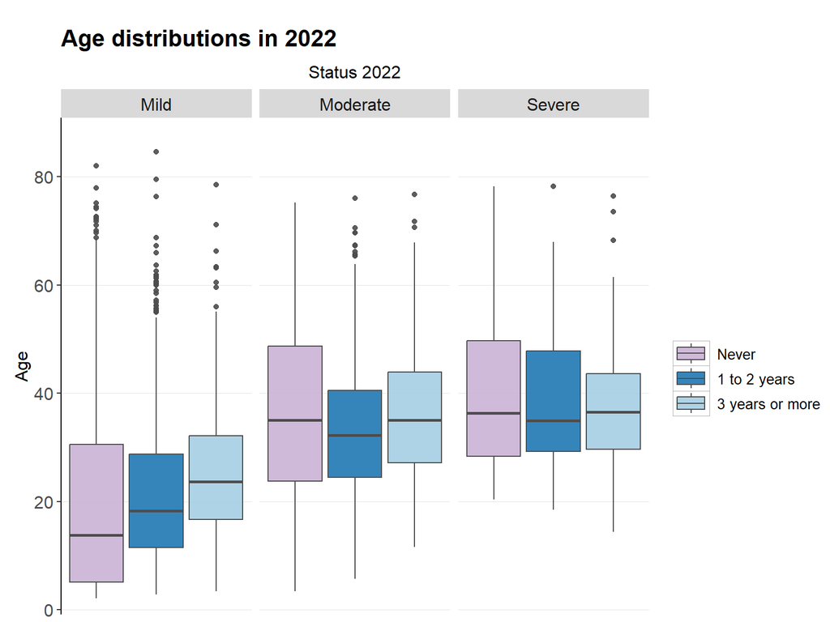

Figure 1: Boxplot of ages of individuals in 2022 adjusting by use of modulators and years using them

The following table shows the distribution of individuals by their 2023 status, based on their 2022 status and modulator use. These distributions indicate that remaining in the same category or transitioning to a more severe category in 2023 was more frequent among individuals not taking Trikafta compared to those taking it.

| Modulator status | Status 2022 | n | Status 2023 Mild | Status 2023 Moderate | Status 2023 Severe | Status 2023 Post-transplant | Status 2023 Deceased |
| --- | --- | --- | --- | --- | --- | --- | --- |
| Trikafta | Mild | 1397 | 96.4 | 3.5 | 0 | 0 | 0.1 |
|  | Moderate | 693 | 25.8 | 71.3 | 2.9 | 0 | 0 |
|  | Severe | 198 | 3.5 | 27.8 | 66.7 | 0 | 2 |
|  | Post-transplant | 1 | 0.0 | 0 | 0 | 100 | 0 |
| None | Mild | 854 | 94.6 | 4.8 | 0.1 | 0 | 0.5 |
|  | Moderate | 175 | 17.7 | 69.7 | 10.9 | 1.1 | 0.6 |
|  | Severe | 49 | 0.0 | 24.5 | 57.1 | 6.1 | 12.2 |
|  | Post-transplant | 323 | 0.0 | 0 | 0 | 94.1 | 5.9 |

Table 2: Percentage of transitions between status from 2022 to 2023 by CFTR modulator status

| Modulator status | Mean difference | Status 2022 | Mean difference |
| --- | --- | --- | --- |
| Trikafta | 4.7 | Mild | 3.8 |
|  |  | Moderate | 6.2 |
|  |  | Severe | 5.1 |
|  |  | Post-transplant | 10.2 |
| None | -0.9 | Mild | -1.4 |
|  |  | Moderate | -0.2 |
|  |  | Severe | 5.1 |
|  |  | Post-transplant | -1.2 |

Table 3: Mean difference of FEV$_1$% predicted values between 2023 and 2022

To better understand the effects of Trikafta, we analyzed changes in status distributions and mean differences in FEV$_1$% predicted values between 2022 and 2023, grouped by the number of years individuals had been taking Trikafta. The tables below present these results. Both tables suggest that there may be meaningful differences in transition probabilities among those taking modulators when years on modulators are included in the models.

| Modulator status | Years on modulator | Status 2022 | n | Status 2023 Mild | Status 2023 Moderate | Status 2023 Severe | Status 2023 Post-transplant | Status 2023 Deceased |
| --- | --- | --- | --- | --- | --- | --- | --- | --- |
| Trikafta | 1 to 2 years | Mild | 934 | 97.8 | 2.1 | 0 | 0 | 0.1 |
|  |  | Moderate | 332 | 45.2 | 54.2 | 0.6 | 0 | 0 |
|  |  | Severe | 65 | 9.2 | 47.7 | 40 | 0 | 3.1 |
|  | 3 years or more | Mild | 463 | 93.7 | 6.3 | 0 | 0 | 0 |
|  |  | Moderate | 361 | 8.0 | 87 | 5 | 0 | 0 |
|  |  | Severe | 133 | 0.8 | 18 | 79.7 | 0 | 1.5 |
| None | Never | Mild | 854 | 94.6 | 4.8 | 0.1 | 0 | 0.5 |
|  |  | Moderate | 175 | 17.7 | 69.7 | 10.9 | 1.1 | 0.6 |
|  |  | Severe | 49 | 0.0 | 24.5 | 57.1 | 6.1 | 12.2 |

Table 4: Percentage of transitions between status from 2022 to 2023 by years on CFTR modulator

[output not shown]

| Modulator status | Years on modulator | Mean difference | Status 2022 | Mean difference |
| --- | --- | --- | --- | --- |
| Trikafta | 1 to 2 years | 8.2 | Mild | 6.3 |
|  |  |  | Moderate | 12.4 |
|  |  |  | Severe | 13.3 |
|  | 3 years or more | -0.4 | Mild | -1.4 |
|  |  |  | Moderate | 0.4 |
|  |  |  | Severe | 1.2 |
| None | Never | -0.9 | Mild | -1.4 |
|  |  |  | Moderate | -0.2 |
|  |  |  | Severe | 5.1 |

Table 5: Mean difference of FEV$_1$% predicted values between 2023 and 2022

By comparing Table 4 to Table 2, and Table 5 to Table 3, we can see that both the distributions and the mean differences indicate that the greatest improvements in lung function occur within the first two years of modulator use. These results also indicate that failing to adjust for years on modulators may obscure the true effect of Trikafta.

These insights are shown in the boxplots below. In panel A, the boxes for groups based only on modulator use (regardless of how long) look quite similar in where they sit and how spread out they are. In panel B, note how the boxes for people who never used Trikafta and those who’ve been on it for three years or more look pretty similar in both spread and position. Additionally, the group using modulators for 1–2 years it’s clearly higher than the others, and shows more positive differences compared to the other groups, regardless of the status of the individual in 2022. That means FEV₁% predicted in 2023 was almost always better than in 2022 for these individuals.

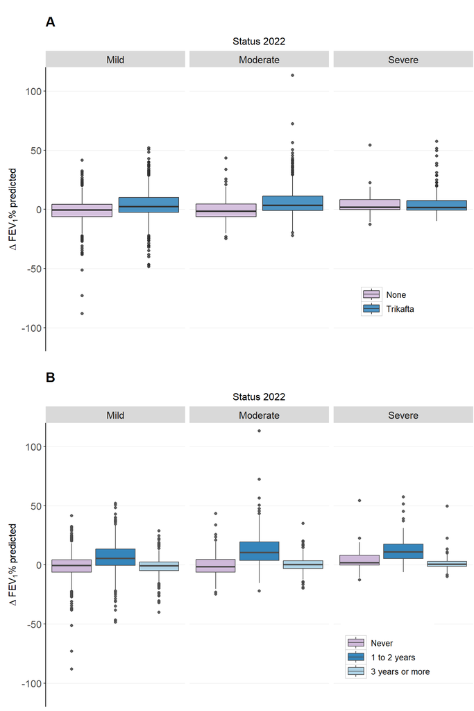

Figure 2: Boxplot of the differences between FEV$_1$% predicted values between 2023 and 2022 adjusting by (A) only use of modulators; (B) use of modulators and years using them

# Predicted differences in FEV$_1$% predicted

To assess the impact of age and CFTR modulator use on lung function, we estimated changes in FEV₁% predicted between 2022 and 2023 using a multivariate linear regression model. The resulting plots illustrate these differences by age and modulator use. Note the variation in slopes between the models and the substantial gap in differences among individuals using modulators according to how long they have been using them. Individuals on modulators for 1–2 years exhibited greater positive changes compared to other groups, regardless of age in 2022, indicating a clear improvement in lung function in 2023.

Model 1. **Linear regression model with binary indicator of modulator use:**

$$\mathbb{E}\left[\, \Delta \text{FEV}_1\% \text{pred}_i \,\right] = \beta_0 + \beta_1 \cdot \text{age}_i + \beta_2 \cdot \text{mod}_{i}$$
$$\Delta\text{FEV}_1\text{\% pred}_i = \text{FEV}_1\text {\% pred}_i \text{ in 2023} - \text{FEV}_1\text {\% pred}_i \text{ in 2022}$$
$$\text{age}_i = \text{age of individual } \mathcal{i} \text{ in 2022}$$
$$\text{mod}_i =
\begin{cases}
1 & \text{if individual } \mathcal{i} \text{ is using Trikafta in both years} \\
0 & \text{if individual } \mathcal{i} \text{ is not using any modulator in both years}
\end{cases}$$

Model 2. **Linear regression model with modulator use stratified by years of treatment:**

$$\mathbb{E}\left[\, \Delta \text{FEV}_1\% \text{pred}_i \,\right] = \beta_0 + \beta_1 \cdot \text{age}_i + \beta_2 \cdot \text{T short}_{i} + \beta_3 \cdot \text{T long}_i$$
$$\text{T short}_i =
\begin{cases}
1 & \text{if individual } \mathcal{i} \text{ have been using Trikafta for 1 to 2 years} \\
0 & \text{ otherwise}
\end{cases}$$
$$\text{T long}_i =
\begin{cases}
1 & \text{if individual } \mathcal{i} \text{ have been using Trikafta for 3 years or more} \\
0 & \text{ otherwise}
\end{cases}$$

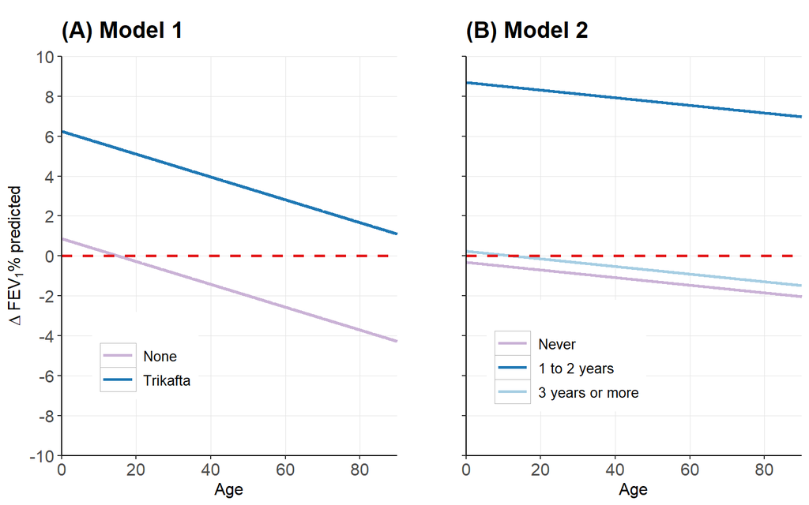

Figure 3: Predicted differences in FEV$_1$% predicted values between 2023 and 2022 adjusted by age and (A) use of modulators; and (B) use of modulators and years using them

| Term | Estimate | Std. error | p.value |
| --- | --- | --- | --- |
| **Model 1** |  |  |  |
| \(\beta_{0}\) | 0.870 | 0.55 | 0.1150 |
| \(\beta_{1}\) | -0.057 | 0.01 | 0.0000 |
| \(\beta_{2}\) | 5.379 | 0.44 | 0.0000 |
| **Model 2** |  |  |  |
| \(\beta_{0}\) | -0.316 | 0.53 | 0.5515 |
| \(\beta_{1}\) | -0.019 | 0.01 | 0.1382 |
| \(\beta_{2}\) | 9.011 | 0.47 | 0.0000 |
| \(\beta_{3}\) | 0.556 | 0.50 | 0.2642 |

Table 6: Table that summarizes the coefficients of the models and their significance

# Transition probabilities

Transition probabilities will be estimated using logistic regression models adjusted for age and modulator use. Two models will be fitted to the data: (1) a model adjusted for age and a binary indicator of modulator use, and (2) a model where modulator use is stratified by the number of years the individual has been taking it. The models will have the following forms:

Model 1. **Logistic regression model with binary indicator of modulator use:**

$$\log \left( \frac{\pi_i}{1 - \pi_i} \right) = \beta_0 + \beta_1 \cdot \text{age}_i + \beta_2 \cdot \text{mod}_{i}$$
$$\pi_i = \text{probability of transitioning to a different state in 2023 for individual } \mathcal{i}$$
$$\text{age}_i = \text{age of individual } \mathcal{i} \text{ in 2022}$$
$$\text{mod}_i =
\begin{cases}
1 & \text{if individual } \mathcal{i} \text{ is using Trikafta in both years} \\
0 & \text{if individual } \mathcal{i} \text{ is not using any modulator in both years}
\end{cases}$$

Model 2. **Logistic regression model with modulator use stratified by years of treatment:**

$$\log \left( \frac{\pi_i}{1 - \pi_i} \right) = \beta_0 + \beta_1 \cdot \text{age}_i + \beta_2 \cdot \text{T short}_{i} + \beta_3 \cdot \text{T long}_i$$
$$\text{T short}_i =
\begin{cases}
1 & \text{if individual } \mathcal{i} \text{ have been using Trikafta for 1 to 2 years} \\
0 & \text{ otherwise}
\end{cases}$$
$$\text{T long}_i =
\begin{cases}
1 & \text{if individual } \mathcal{i} \text{ have been using Trikafta for 3 years or more} \\
0 & \text{ otherwise}
\end{cases}$$

## From mild to moderate

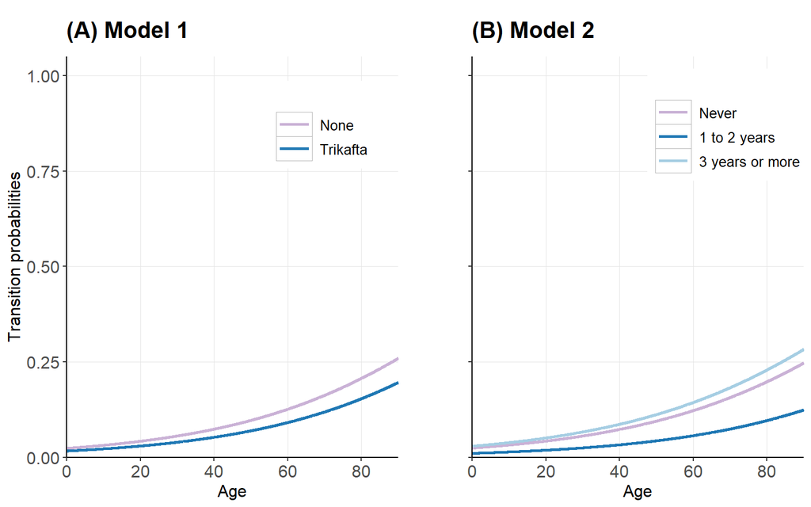

Figure 4: Predicted probabilities of transitioning from mild in 2022 to moderate in 2023 adjusted by age and (A) use of modulators; and (B) use of modulators and years using them

| Term | Estimate | Std. error | p.value |
| --- | --- | --- | --- |
| **Model 1** |  |  |  |
| \(\beta_{0}\) | -3.706 | 0.24 | 0.0000 |
| \(\beta_{1}\) | 0.030 | 0.01 | 0.0000 |
| \(\beta_{2}\) | -0.362 | 0.22 | 0.0970 |
| **Model 2** |  |  |  |
| \(\beta_{0}\) | -3.675 | 0.24 | 0.0000 |
| \(\beta_{1}\) | 0.028 | 0.01 | 0.0000 |
| \(\beta_{2}\) | -0.839 | 0.28 | 0.0026 |
| \(\beta_{3}\) | 0.184 | 0.25 | 0.4646 |

Table 7: Table that summarizes the coefficients of the models and their significance

## From mild to severe

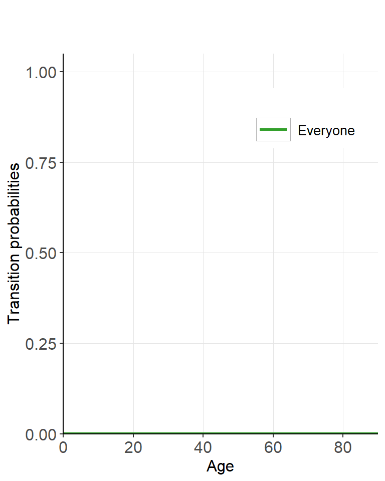

Figure 5: Predicted probabilities of transitioning from mild in 2022 to severe in 2023. Age, use of modulator and years using them were not significant for these probabilities

| Term | Estimate | Std. error | p.value |
| --- | --- | --- | --- |
| **Model 1** |  |  |  |
| \(\beta_{0}\) | -7.719 | 1 | 0 |
| **Model 2** |  |  |  |
| \(\beta_{0}\) | -7.719 | 1 | 0 |

Table 8: Table that summarizes the coefficients of the models and their significance

## From mild to deceased

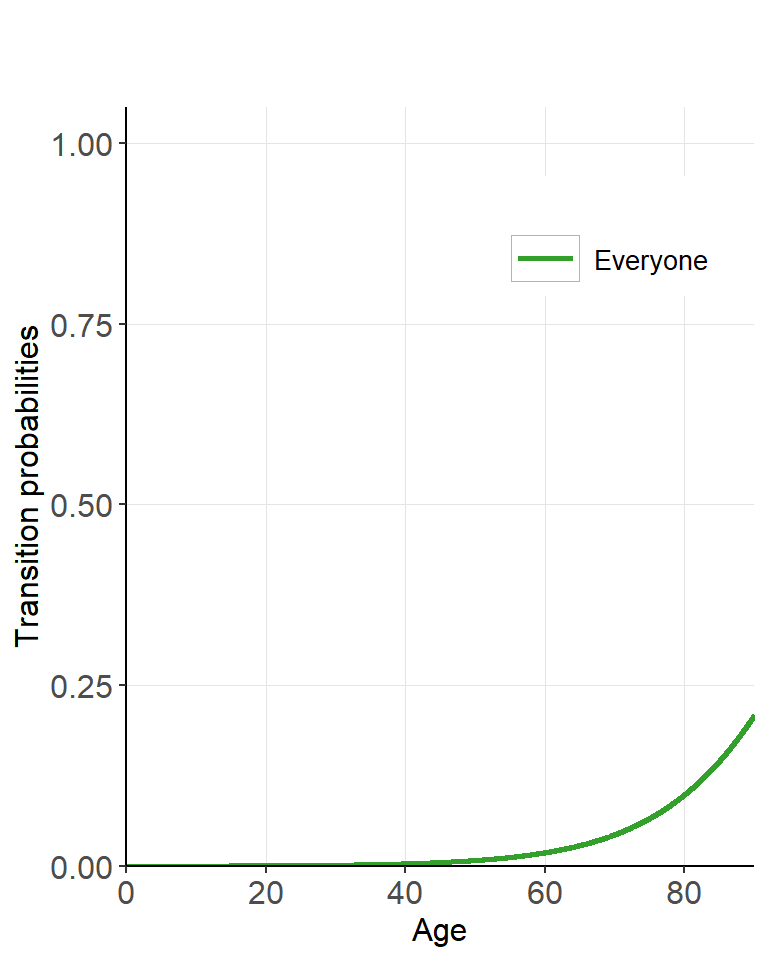

Figure 6: Predicted probabilities of transitioning from mild in 2022 to deceased in 2023 adjusted by age. Use of modulators and years using them were not significant for these probabilities

| Term | Estimate | Std. error | p.value |
| --- | --- | --- | --- |
| **Model 1** |  |  |  |
| \(\beta_{0}\) | -9.229 | 1.29 | 0e+00 |
| \(\beta_{1}\) | 0.088 | 0.02 | 2e-04 |
| **Model 2** |  |  |  |
| \(\beta_{0}\) | -9.229 | 1.29 | 0e+00 |
| \(\beta_{1}\) | 0.088 | 0.02 | 2e-04 |

Table 9: Table that summarizes the coefficients of the models and their significance

## From moderate to mild

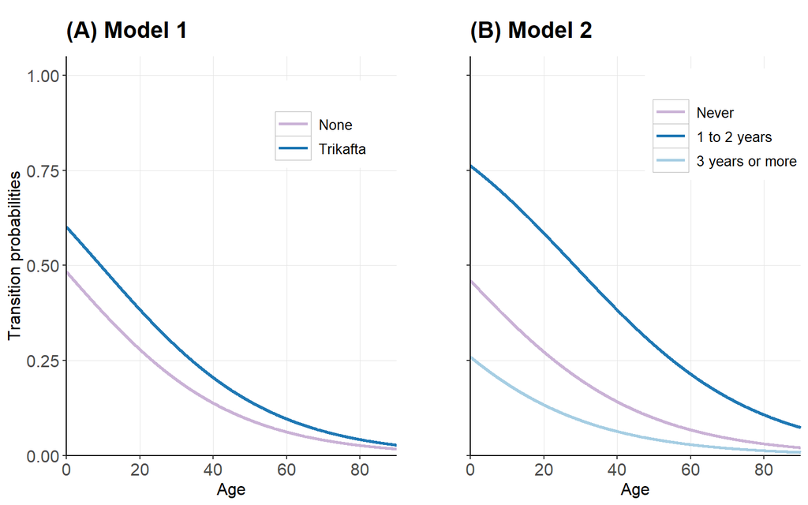

Figure 7: Predicted probabilities of transitioning from moderate in 2022 to mild in 2023 adjusted by age and (A) use of modulators; and (B) use of modulators and years using them

| Term | Estimate | Std. error | p.value |
| --- | --- | --- | --- |
| **Model 1** |  |  |  |
| \(\beta_{0}\) | -0.068 | 0.29 | 0.8152 |
| \(\beta_{1}\) | -0.044 | 0.01 | 0.0000 |
| \(\beta_{2}\) | 0.477 | 0.22 | 0.0327 |
| **Model 2** |  |  |  |
| \(\beta_{0}\) | -0.161 | 0.30 | 0.5887 |
| \(\beta_{1}\) | -0.041 | 0.01 | 0.0000 |
| \(\beta_{2}\) | 1.324 | 0.23 | 0.0000 |
| \(\beta_{3}\) | -0.890 | 0.28 | 0.0016 |

Table 10: Table that summarizes the coefficients of the models and their significance

## From moderate to severe

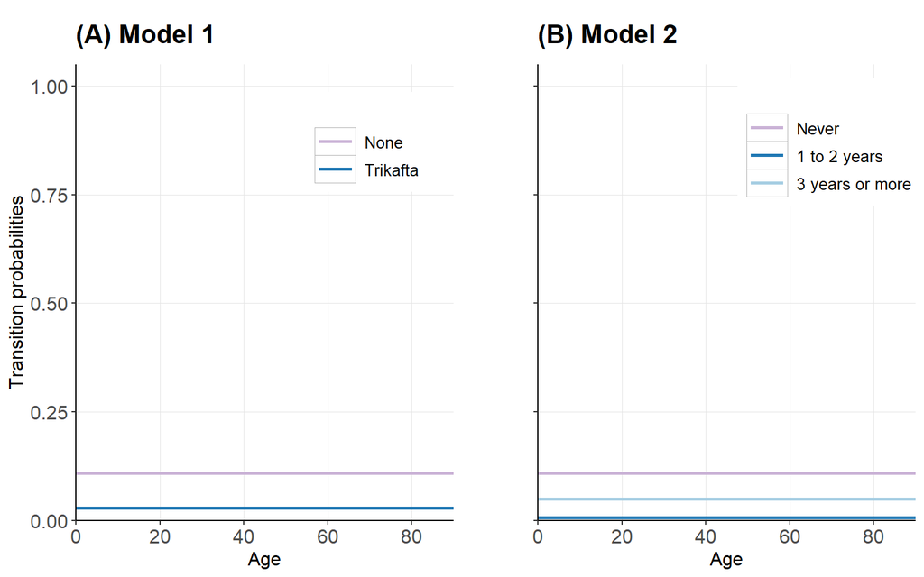

| Term | Estimate | Std. error | p.value |
| --- | --- | --- | --- |
| **Model 1** |  |  |  |
| \(\beta_{0}\) | -2.105 | 0.24 | 0.0000 |
| \(\beta_{2}\) | -1.411 | 0.33 | 0.0000 |
| **Model 2** |  |  |  |
| \(\beta_{0}\) | -2.105 | 0.24 | 0.0000 |
| \(\beta_{2}\) | -3.001 | 0.75 | 0.0001 |
| \(\beta_{3}\) | -0.842 | 0.34 | 0.0140 |

Table 11: Table that summarizes the coefficients of the models and their significance

## From moderate to deceased

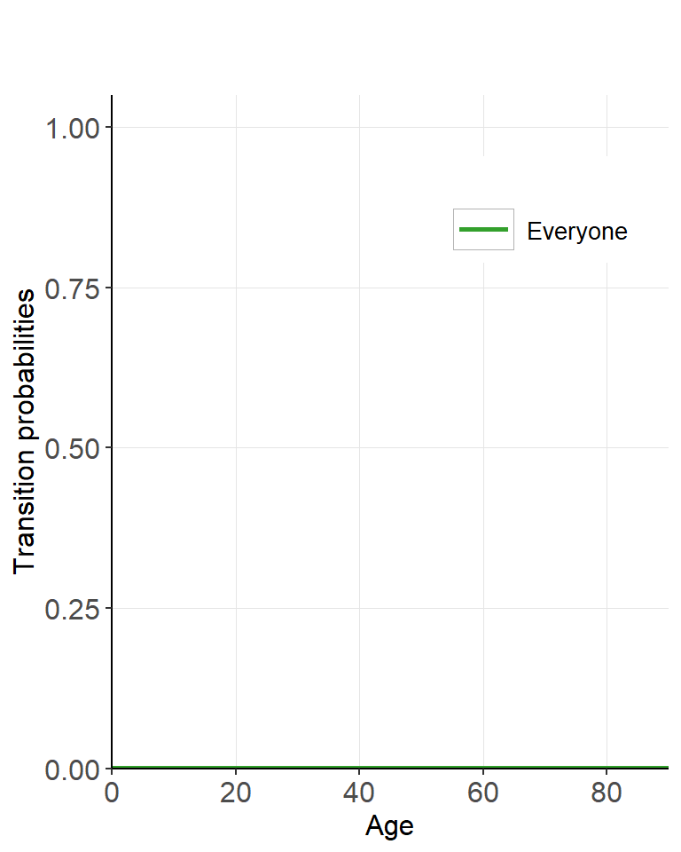

Figure 9: Predicted probabilities of transitioning from moderate in 2022 to deceased in 2023. Age, use of modulators and years using them were not significant for these probabilities

| Term | Estimate | Std. error | p.value |
| --- | --- | --- | --- |
| **Model 1** |  |  |  |
| \(\beta_{0}\) | -6.765 | 1 | 0 |
| **Model 2** |  |  |  |
| \(\beta_{0}\) | -6.765 | 1 | 0 |

Table 12: Table that summarizes the coefficients of the models and their significance

## From severe to moderate

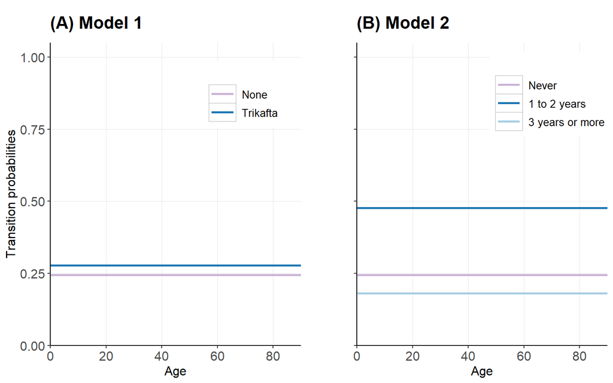

Figure 10: Predicted probabilities of transitioning from severe in 2022 to moderate in 2023 adjusted (A) use of modulators; and (B) use of modulators and years using them. Age was not significant for these probabilities

| Term | Estimate | Std. error | p.value |
| --- | --- | --- | --- |
| **Model 1** |  |  |  |
| \(\beta_{0}\) | -1.126 | 0.33 | 0.0007 |
| \(\beta_{2}\) | 0.170 | 0.37 | 0.6433 |
| **Model 2** |  |  |  |
| \(\beta_{0}\) | -1.126 | 0.33 | 0.0007 |
| \(\beta_{2}\) | 1.034 | 0.41 | 0.0127 |
| \(\beta_{3}\) | -0.387 | 0.40 | 0.3347 |

Table 13: Table that summarizes the coefficients of the models and their significance

## From severe to mild

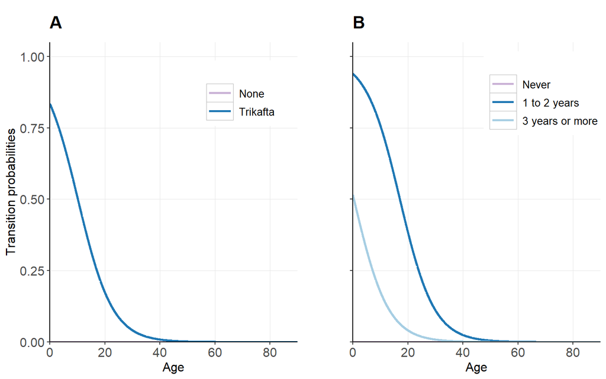

Figure 11: Predicted probabilities of transitioning from severe in 2022 to mild in 2023 adjusted by age and (A) use of modulators; and (B) use of modulators and years using them

| Term | Estimate | Std. error | p.value |
| --- | --- | --- | --- |
| **Model 1** |  |  |  |
| \(\beta_{0}\) | -15.349 | 2236.25 | 0.9945 |
| \(\beta_{1}\) | -0.159 | 0.06 | 0.0083 |
| \(\beta_{2}\) | 16.964 | 2236.25 | 0.9939 |
| **Model 2** |  |  |  |
| \(\beta_{0}\) | -15.315 | 2255.16 | 0.9946 |
| \(\beta_{1}\) | -0.161 | 0.06 | 0.0114 |
| \(\beta_{2}\) | 18.062 | 2255.16 | 0.9936 |
| \(\beta_{3}\) | 15.371 | 2255.16 | 0.9946 |

Table 14: Table that summarizes the coefficients of the models and their significance

## From severe to transplant

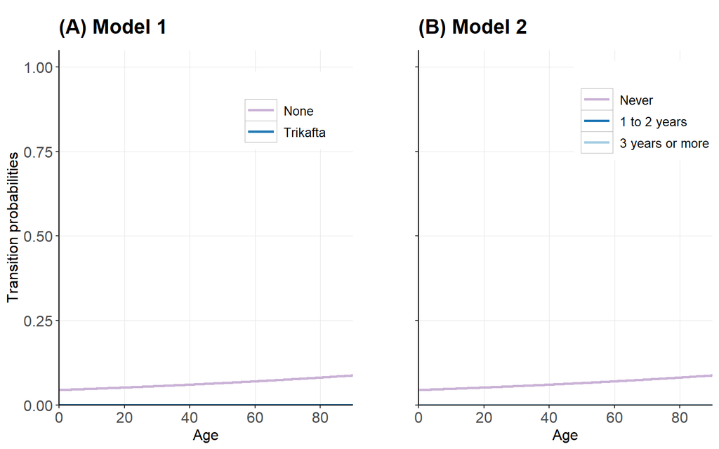

Figure 12: Predicted probabilities of transitioning from severe in 2022 to transplant in 2023 adjusted by age and (A) use of modulators; and (B) use of modulators and years using them

| Term | Estimate | Std. error | p.value |
| --- | --- | --- | --- |
| **Model 1** |  |  |  |
| \(\beta_{0}\) | -3.061 | 1.79 | 0.0876 |
| \(\beta_{1}\) | 0.008 | 0.04 | 0.8418 |
| \(\beta_{2}\) | -19.813 | 3423.28 | 0.9954 |
| **Model 2** |  |  |  |
| \(\beta_{0}\) | -3.061 | 1.79 | 0.0876 |
| \(\beta_{1}\) | 0.008 | 0.04 | 0.8418 |
| \(\beta_{2}\) | -19.820 | 5973.88 | 0.9974 |
| \(\beta_{3}\) | -19.809 | 4177.16 | 0.9962 |

Table 15: Table that summarizes the coefficients of the models and their significance

## From severe to deceased

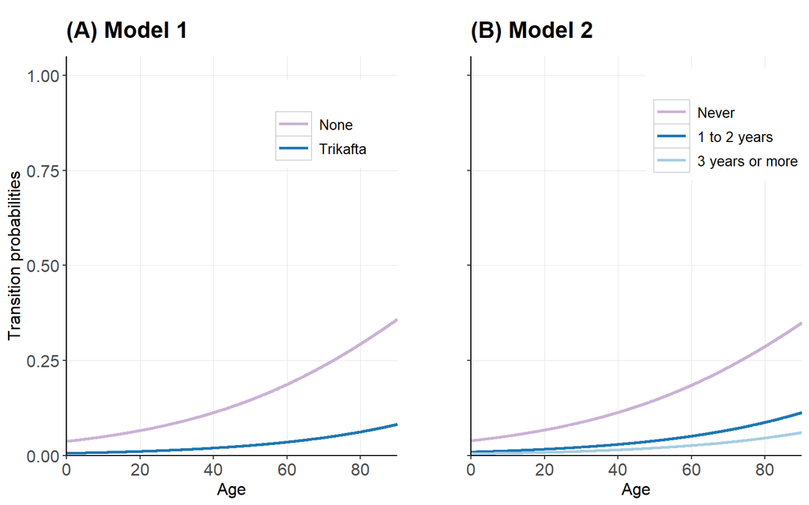

Figure 13: Predicted probabilities of transitioning from severe in 2022 to deceased in 2023 adjusted by age and (A) use of modulators; and (B) use of modulators and years using them

| Term | Estimate | Std. error | p.value |
| --- | --- | --- | --- |
| **Model 1** |  |  |  |
| \(\beta_{0}\) | -3.239 | 1.13 | 0.0040 |
| \(\beta_{1}\) | 0.030 | 0.02 | 0.1958 |
| \(\beta_{2}\) | -1.830 | 0.67 | 0.0066 |
| **Model 2** |  |  |  |
| \(\beta_{0}\) | -3.198 | 1.12 | 0.0042 |
| \(\beta_{1}\) | 0.029 | 0.02 | 0.2069 |
| \(\beta_{2}\) | -1.436 | 0.84 | 0.0892 |
| \(\beta_{3}\) | -2.115 | 0.84 | 0.0121 |

Table 16: Table that summarizes the coefficients of the models and their significance

## From transplant to deceased

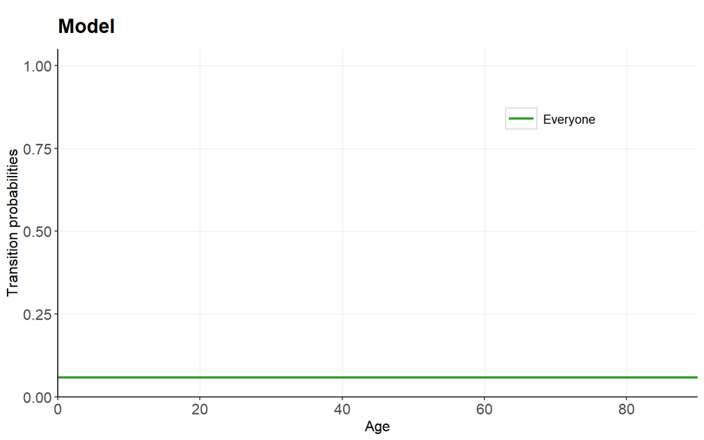

| Term | Estimate | Std. error | p.value |
| --- | --- | --- | --- |
| **Model 1** |  |  |  |
| \(\beta_{0}\) | -2.776 | 0.24 | 0 |
| **Model 2** |  |  |  |
| \(\beta_{0}\) | -2.776 | 0.24 | 0 |

Table 17: Table that summarizes the coefficients of the models and their significance

## From mild, moderate, or severe to lost-to-follow-up

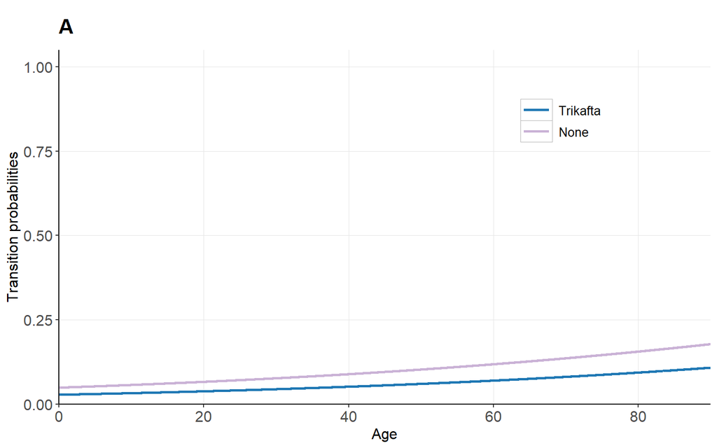

Figure 15: Predicted probabilities of transitioning from mild, moderate, or severe status in 2022 to lost-to-follow-up in 2023 adjusted by age and use of modulators

| Term | Estimate | Std. error | p.value |
| --- | --- | --- | --- |
| **Model 1** |  |  |  |
| \(\beta_{0}\) | -2.962 | 0.17 | 0e+00 |
| \(\beta_{1}\) | 0.016 | 0.00 | 2e-04 |
| \(\beta_{2}\) | -0.580 | 0.15 | 1e-04 |

Table 18: Table that summarizes the coefficients of the model and their significance

# Comorbidities

## Pulmonary exacerbations (PEX)

Pulmonary exacerbations are the number of hospitalizations because of pulmonary reasons in 2023.

| Modulator status | Status 2023 | Exacerbation rates |
| --- | --- | --- |
| None | Mild | 0.07 |
|  | Moderate | 0.39 |
|  | Severe | 0.69 |
| Trikafta | Mild | 0.04 |
|  | Moderate | 0.12 |
|  | Severe | 0.24 |

Table 19: Table that summarizes the proportions of pulmonary exacerbations by disease severity and use of modulators

| Modulator status | Years on modulator | PEX rates | Status 2023 | PEX rates |
| --- | --- | --- | --- | --- |
| None | Never | 0.15 | Mild | 0.07 |
|  |  |  | Moderate | 0.39 |
|  |  |  | Severe | 0.69 |
| Trikafta | 1 to 2 years | 0.04 | Mild | 0.03 |
|  |  |  | Moderate | 0.09 |
|  |  |  | Severe | 0.21 |
|  | 3 years or more | 0.11 | Mild | 0.05 |
|  |  |  | Moderate | 0.14 |
|  |  |  | Severe | 0.24 |

Table 20: Table that summarizes the proportions of pulmonary exacerbations by disease severity and years using modulators

# New diagnosis

| Age distribution | n | prop |
| --- | --- | --- |
| 0-1 | 44 | 0.677 |
| 1-2 | 4 | 0.062 |
| 18+ | 15 | 0.231 |
| 2-18 | 2 | 0.031 |

Table 21: Table that summarizes the number of new diagnosis in 2023 by age group